# Введение в R

2023-11-01

## Введение

Самое главное - вам не понадобятся знание высшей математики (боже упаси). Всё изложенное в курсе будет максимально адаптивно. В случае возникновения вопросов можно связаться со мной по почте v.vinogradov@inno.mgimo.ru или задать вопрос после пар. Есть также чудесный сайт, именуемый [Stackoverflow](https://stackoverflow.com/), на котором есть ответы **НА ВСЕ ВОПРОСЫ**.

**Как установить этот ваш R?** Очень просто. Требуется скачать ровно два файла: сам R и IDE к нему (я использую R-studio и вам советую). IDE это графический интерфейс, который облегчит работу с языком. Программа будет давать подсказки при вводе программ, подчеркивать ошибки в синтаксисе и выдавать по запросу продвинутую справку о том, как использовать команды. не усложняйте себе жизнь, скачайте R-studio.

[R для Windows можно скачать отсюда.](https://cran.r-project.org/bin/windows/base/)

[R для яблочников находится вот тут.](https://cran.r-project.org/bin/macosx/)

Там же подробная инструкция по установке (если коротко: надо кликнуть на программу и разрешить установку) и различные советы по установке. Опять же, их можно задать мне на почту или после пар.

[Rstudio для Windows.](https://download1.rstudio.org/electron/windows/RStudio-2022.12.0-353.exe)

[Rstudio для Джобсофилов и ТимКуколюбов.](https://download1.rstudio.org/electron/macos/RStudio-2022.12.0-353.dmg)

[Сайт Rstudio.](https://posit.co/download/rstudio-desktop/)

Проблемы могут возникнуть у пользователей mac - как правило IOS ругается на установку из внешнего источника. Пути преодоления описаны в инструкции (или можно опять же задать вопросы мне). Ура, мы установили R! Теперь можно приступать к освоению программирования.

## О Rstudio

[figure not shown]

[figure not shown]

R является статистическим языком программирования, т.е. создавался именно для статистического анализа, хотя сейчас на нём можно писать полноценные web-приложения (c помощью библиотеки **shiny**), парсить веб-сайты и тг-каналы. Но всё равно придётся начать с азов.

## Как это вообще работает и какие типы данных бывают?

### Переменные

Базовой единицей в R является *переменная*. Прям как в математике. И в **переменную** вы можете поместить всё что угодно, хоть число, хоть слово. Рассмотрим вот такие примеры:

```r
x <- 1
y <- 2
x + y
```

```
## [1] 3
```

Так, что мы сделали? Мы создани переменную через операцию присвоения (она выполняется знаком <-, набираемым вручную или с помощью сочетания клавиш **“Alt” + “-”**), почле чего выполнили математическую операцию с данными числами. Переменные нужны, дабы облегчить вам жизнь и не писать каждый раз однотипные вычисления. Так, например, мы можем сохранить результат суммирования x и y для дальнейшего использования:

```r
x <- 1
y <- 2
z <- x + y
z + x
```

```
## [1] 4
```

```r
z + y
```

```
## [1] 5
```

Теперь попробуем запомнить в переменную категориальные данные (character). **ВАЖНО: ТЕКСТ, НЕ ЯВЛЯЮЩИЙСЯ ФУНКЦИЕЙ ИЛИ КОМАНДОЙ, НУЖНО ПИСАТЬ В КАВЫЧКАХ**. Можно присваивать отдельные слова, предложения и даже тексты (что нам пригодится в будущем для контент-анализа):

```r
x <- "mgimo"
y <- "university"
```

Естественно, классическая математика не прокатит с данными переменными. Можете попробовать просуммировать x и y (спойлер: R начнёт ругаться). Зато можно выводить значения категориальной переменной в консоль и даже комбинировать значения разных переменных. Для этого нам понадобится команда **paste** или **paste0**, позволяющие извлекать значения нескольких переменных и комбинировать их с текстом:

```r
x <- "mgimo"
y <- "university"
paste0(x, sep = " ", y, sep = " ", "is my dream" )
```

```
## [1] "mgimo university is my dream"
```

Кстати, параметр *sep = ““* часто используется во многих командах и обозначает сепаратор (разделитель), который вы хотите использовать между отдельными переменными. **Совсем забыл**, мы же должны сделать самое необходимое: **поприветствовать этот мир**. Для этого подойдет команда **print**, которая выводит значение, указанное в скобках:

```r
print("Hello, world")
```

```
## [1] "Hello, world"
```

**Print** также может выводить значение переменной (но только одной):

```r
x <- 1
y <- 2
print(x)
```

```
## [1] 1
```

```r
print(y)
```

```
## [1] 2
```

Для вывода двух значений лучше использовать **paste0**:

```r
x <- 1
y <- 2
paste0(x, sep = " ", y)
```

```
## [1] "1 2"
```

Непонятно, где у нас x, а где y. Нужно добавить пояснение:

```r
x <- 1
y <- 2
paste0("x =", sep = " ", x, sep = ", ", "y =", sep = " ", y)
```

```
## [1] "x = 1, y = 2"
```

### Векторы

Вот теперь мы можем отличить x от y, способны вывести значения переменных в консоль. Время познакомиться с группой данных, то есть с **множествами**. Представим, что нам требуется провести операцию с несколькими числами сразу. Для этого необходимо создать группу данных или на языке R **вектор**. Вектор создается командой c(), в которой необходимо указать данные через запятую.

```r
#создаём числовой вектор
x <- c(1, 2, 3)
y <- c(5, 6, 7)
#данная операция суммирует числа в векторе
x + y
```

```
## [1]  6  8 10
```

```r
#кстати, вот такой решёткой создаются комментарии. Пишите комментарии, чтобы не потеряться в собственном коде
#числа в векторах суммируются по их позиции в векторе, т.е. при сложении x и y вместе складываются числа с порядковым номером 1, затем 2 и т.д. Если один вектор длиннее другого, то R начнёт складывать короткий вектор сначала.
z <- x + y
z + x
```

```
## [1]  7 10 13
```

```r
z + y
```

```
## [1] 11 14 17
```

```r
x1 <- c(1, 2, 3, 20)
y1 <- c(5, 6, 7)
y1 + x1
```

```
## [1]  6  8 10 25
```

Важно отметить, что в вектор можно складировать текст. Для этого существует два способа: обычный, эль классик, с помощью команды **c()** и правильный с использованием команды **factor()**. Отличие состоит в том, что команда **factor** автоматически определяет типологию, то есть воспринимает слова внутри вектора как некие классы, что весьма удобно при обработке социологии. Продемонстриуем с помощью кода.

```r
x <- c("man", "man", "man", "man", "man", "woman", "woman", "woman", "student")
y <- factor(x)
x
```

```
## [1] "man"     "man"     "man"     "man"     "man"     "woman"   "woman"
## [8] "woman"   "student"
```

```r
y
```

```
## [1] man     man     man     man     man     woman   woman   woman   student
## Levels: man student woman
```

R в первом случае просто составил вектор с рандомными словами, тогда как во втором кейсе создал типологию. В последующих уроках мы научимся подобные типологии визуализировать, а пока перейдем к другому типу даных: к таблицам.

### Матрицы и таблицы

Векторы это, конечно, очень хорошо, но что нам делать с комплексными индикаторами? Для таких задач в R используются **матрицы (matrix)** и **таблицы (dataframes)**. Скажу стразу: и то, и другое является привычной нам таблицей с небольшими отличиями, о которых поведает незамысловаятая таблица:

| Матрица | Датафрейм |
| --- | --- |
| Набор однотипных данных. | Набор разнотипных данных, хранящихся в разных столбцах. |
| Имеет фиксированное количество строк и столбцов. | Имеет переменное количество строк и столбцов. |
| Код с матрицей быстрее, но ограничен типом данных. | Код медленнее, но данные могут быть разноплановыми. |

Матрица создаётся командой **matrix()**, в качестве параметров указывается вектор, желаемое количество строк и рядов. Фактически это отражает суть матрицы: это сочетание векторов, организованное по заданным параметрам рядов и столбцов. Обратите внимание: вектор располагается по столбцам, то есть если количество строк меньше длины вектора, то значения будут переходить на следующий столбец.

```r
#матрица из одного вектора (он дублируется в каждом столбце)
matrix(c(1, 2, 3), nrow = 3, ncol = 3)
```

```
##      [,1] [,2] [,3]
## [1,]    1    1    1
## [2,]    2    2    2
## [3,]    3    3    3
```

```r
#матрица из одного вектора, длина которого равна длине матрицы
matrix(c(1, 2, 3, 4, 5, 6, 7, 8, 9), nrow = 3, ncol = 3)
```

```
##      [,1] [,2] [,3]
## [1,]    1    4    7
## [2,]    2    5    8
## [3,]    3    6    9
```

```r
#матрица из трёх разных векторов
matrix(c(c(1, 2, 3), c(4, 5, 6), c(7, 8, 9)), nrow = 3, ncol = 3)
```

```
##      [,1] [,2] [,3]
## [1,]    1    4    7
## [2,]    2    5    8
## [3,]    3    6    9
```

```r
#в чём разница между предыдущими двумя кейсами? Мы используем разное количество векторов для формирования матрицы, что понадобится в будущем. Продемонстрируем то же самое, но используя переменные.

x <- c(1, 2, 3)
y <- c(4, 5, 6)
z <- c(7, 8, 9)
xyz <- c(1, 2, 3, 4, 5, 6, 7, 8, 9)

#для объединения векторов нужно создать вектор из уже сущетвующих. Проверим, будут ли они равнозначны, используя сравнение

c(x, y, z) == xyz
```

```
## [1] TRUE TRUE TRUE TRUE TRUE TRUE TRUE TRUE TRUE
```

```r
#теперь можно провести операции по созданию матрицы из векторов с помощью переменных

matrix(xyz, nrow = 3, ncol = 3)
```

```
##      [,1] [,2] [,3]
## [1,]    1    4    7
## [2,]    2    5    8
## [3,]    3    6    9
```

```r
matrix(c(x, y, z), nrow = 3, ncol = 3)
```

```
##      [,1] [,2] [,3]
## [1,]    1    4    7
## [2,]    2    5    8
## [3,]    3    6    9
```

Мы выполнили одну и ту же операцию двумя способами. Выборо оного напрямую зависит от рабочей ситуации. Но чаще всего вы будете работать с таблицами, а как преобразовать матрицу в таблицу расскажу в блоке об импорте данных из внешних источников. Сейчас стоит освоить второй тип таблиц - датафреймы. Создадим таблицу с разными типами переменных (таблица создается с помощью команды **data.frame**)

```r
x <- c(1, 2, 3, 4, 5, 6, 7)
y <- factor(c("man", "woman", "student", "cat", "man", "man", "cat"))
z <- c("2006-06-22", "2006-06-22", "2017-02-22", "2007-02-12", "2222-02-23", "2007-06-22", "2006-06-22" )
data.frame(x, y, z)
```

```
##   x       y          z
## 1 1     man 2006-06-22
## 2 2   woman 2006-06-22
## 3 3 student 2017-02-22
## 4 4     cat 2007-02-12
## 5 5     man 2222-02-23
## 6 6     man 2007-06-22
## 7 7     cat 2006-06-22
```

```r
#если длина одного из векторов меньше максимальной длины используемого вектора, R выдаст ошибку. При этом возможно использовать константное значение

b <- 1
data.frame(x, y, z, b)
```

```
##   x       y          z b
## 1 1     man 2006-06-22 1
## 2 2   woman 2006-06-22 1
## 3 3 student 2017-02-22 1
## 4 4     cat 2007-02-12 1
## 5 5     man 2222-02-23 1
## 6 6     man 2007-06-22 1
## 7 7     cat 2006-06-22 1
```

### Импорт и экспорт данных

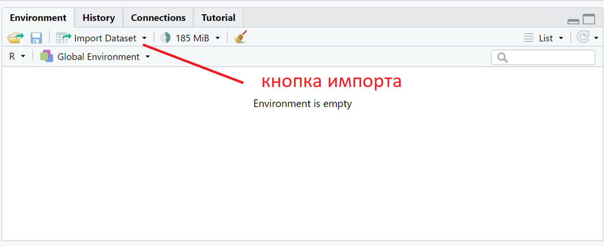

[figure not shown]

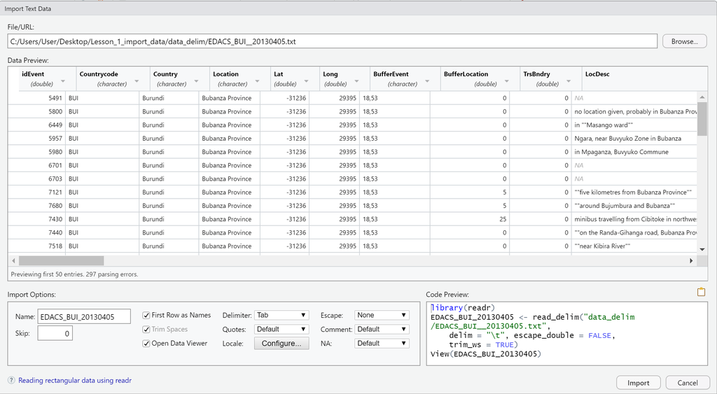

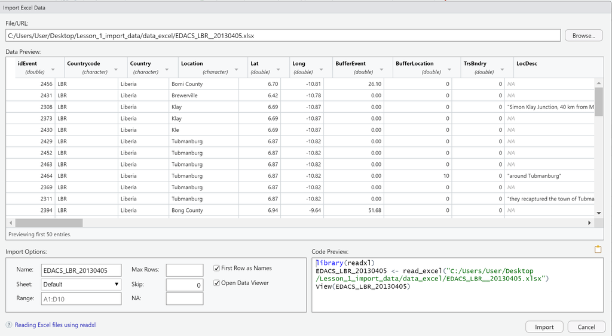